# Befolkningsutvecklingen i Avesta

Befolkningsutvecklingen i Avesta  
- en kort analys

Rapporten är skapad av Samhällsanalys, Region Dalarna  
Senast uppdaterad: 2024-07-15

# Sammanfattning

För mer info om statistiken, klicka på rutan nedan:

**Mer information om statistiken**

I folkmängden som SCB publicerar ingår personer som är folkbokförda i landet. För att den som flyttar till Sverige ska bli folkbokförd ska personen ha för avsikt och rätt att stanna i Sverige i minst ett år. För personer som inte är medborgare i ett EU-land innebär det att det krävs ett uppehållstillstånd som gäller minst 12 månader för att bli folkbokförd. Till följd av Rysslands invasion av Ukraina den 24 februari 2022 har Europeiska unionen (EU) beslutat att aktivera massflyktsdirektivet, vilket innebär att personer från Ukraina utan individuell prövning ska erbjudas tidsbegränsat uppehålls- och arbetstillstånd inom EU. Personer som får uppehållstillstånd enligt massflyktsdirektivet ska i regel inte bli folkbokförda och ingå i den officiella befolkningsstatistiken. Läs mer [här](https://www.scb.se/hitta-statistik/statistik-efter-amne/befolkning/befolkningens-sammansattning/befolkningsstatistik/produktrelaterat/Fordjupad-information/statistik-om-invandring---fragor-och-svar/).

Under 2023 inledde Skatteverket ett arbete med att avregistrera flera tusen folkbokförda personer som vid en granskning visat sig inte längre bo i Sverige. I folkbokföringen har dessa registrerats som utvandrade till okänt utvandringsland. Antal utvandrade från Avesta var år 2023 86 personer, vilket är elva fler än under 2022 och runt 30 fler än 2021. Det är därför möjligt att avregistreringarna har haft en viss påverkan på befolkningsutvecklingen i Avesta under 2023. Läs mer [här](https://www.scb.se/pressmeddelande/sverige-gar-mot-lagsta-befolkningsokningen-pa-manga-ar/).

# 1 Hur har befolkningen förändrats?

I likhet med flera bruksorter i de södra delarna av Dalarna har befolkningen i Avesta minskat under en lång period, från ca 28 700 invånare år 1968 till ungefär 22 800 invånare år 2023.

Befolkningen minskar under en överväldigande majoritet av åren, vilket syns tydligt i diagrammet nedan. Det stora undantaget var i samband med flyktingkrisen 2015-2016, när Avestas befolkning ökade med mer än 1100 personer. Därefter minskade befolkningen under några år, vilket till stor del kan förklaras med att personer som flyttade till Avesta i samband med flyktingkrisen lämnade för andra delar av Sverige. Under 2022 ökade Avestas befolkning något (7 personer), men denna ökning följdes av en en betydligt större minskning 2023 (-179 personer).

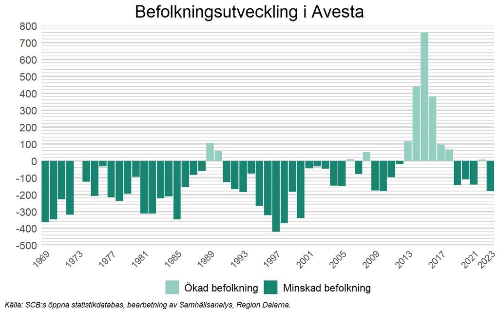

I fortsättningen av denna korta analys delas befolkningsutveckling upp i dess komponenter, födelsenetto, dvs. nettot av födda och döda, och flyttnetto, dvs. nettot av inrikes och utrikes flyttar. Vi börjar med födelsenettot.

# 2 Födelsenetto

En trend är att det dör färre personer i Avesta idag än det gjorde längre tillbaka i tiden. Med undantag för Corona-pandemin, 2020 och 2021, dör idag runt 270 personer under ett normalt år i kommunen. Detta kan jämföras med runt 300 personer per år i början av 2000-talet och ibland över 350 personer per år på 1970- och 1980-talet. Detta samtidigt som befolkningen idag är betydligt äldre. Denna utveckling härrör sannolikt till utveckling inom det medicinska området. Befolkningens medelålder ökar över tid och har gjort så länge.

Även när det gäller antalet födslar är trenden negativ. Under 1960- och 1970-talen föddes ofta över 300 barn i Avesta per år, något som bara har hänt vid ett tillfället (2018) sedan tidigt 1990-tal. En tydlig negativ trend inleddes i samband med finanskrisen i början på 1990-talet, men under 2010-talet ökade födslarna igen, något som sannolikt har att göra med att Avestas befolkning då ökade till följd av högre invandring (mer om det senare). År 2023 föddes 200 barn, vilket är den lägsta siffran sedan 2013.

Med undantag för 2018, har nettot mellan födda och döda, se de svarta linjerna i diagrammet nedan, varit negativt i Avesta under varje år sedan början av 1990-talet. Hur många invånare som kommunen tappar på grund av det varierar relativt mycket mellan åren, men det har skett en tydlig ökning under de senaste åren. År 2023 minskade befolkningen med 70 personer till följd av ett negativt födelsenetto.

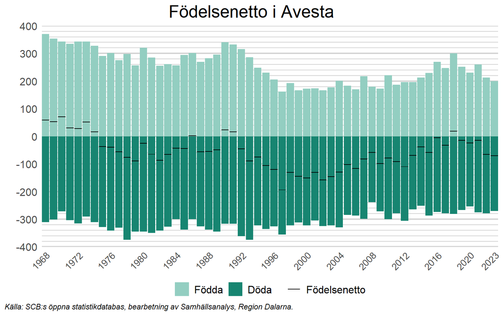

# 3 Flyttnetto

Den andra komponenten som styr befolkningsutvecklingen är det så kallade flyttnettot. Detta kan i sin tur delas upp i två komponenter, inrikes och utrikes flyttar. I det här avsnittet undersöker vi först flyttnettot, för att därefter titta på de två komponenterna.

Nettot mellan antalet personer som flyttar till och från Avesta varierar relativt mycket mellan åren, men ligger normalt mellan +/- 100 personer. Undantaget var åren runt flyktingkrisen, när mer än 1600 personer netto flyttade till kommunen mellan 2014 och 2016. Under 2023 var flyttnettot återigen negativt (-113 personer), vilket är i linje med de flesta åren på senare tid.

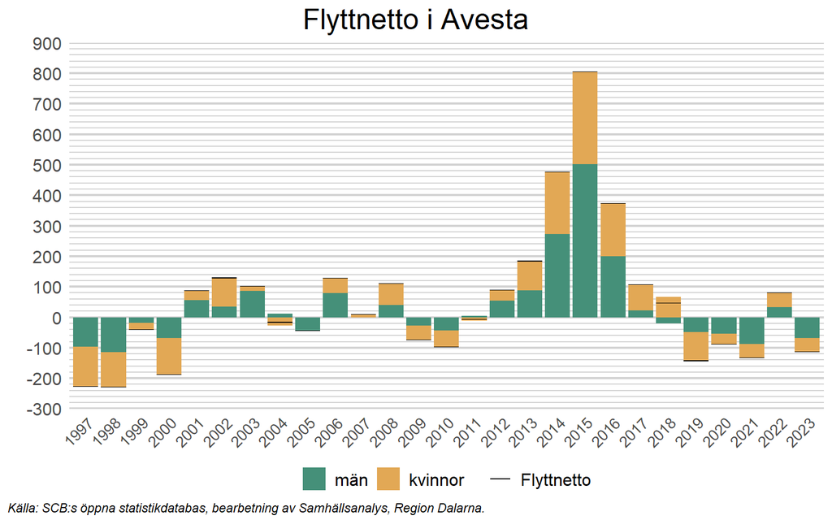

## 3.1 Utrikes flyttnetto

Som vi berörde i föregående avsnitt flyttade många till Avesta under åren runt flyktingkrisen, vilket till stor del kan förklaras av att invandringen då var stor. I slutet av 1990-talet var invandringen ofta väldigt låg och till och med negativ under vissa år (fler utvandrade än invandrade), men därefter skedde en gradvis ökning innan den stora toppen 2016. Därefter minskade invandringen tydligt, men låg på relativt höga nivåer fram till 2019. På senare år syns effekterna av en tydligt stramare nationell migrationspolitik, då allt färre invandrar till Avesta. Under 2023 var det utrikes flyttnettot 0 personer, det lägsta nettot sedan 1997. Detta kan sannolikt delvis förklaras av de avregistreringar av utvandrade som Skattemyndigheten genomförde under 2023 (se informationsruta ovan), men den främsta anledningen är en stramare migrationspolitik.

Generellt invandrar ungefär lika många kvinnor och män till Avesta.

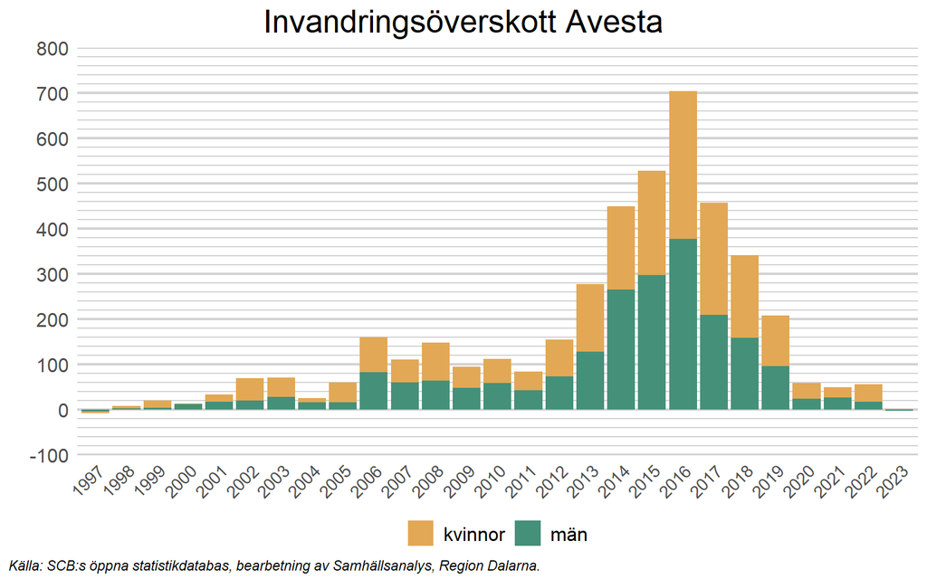

## 3.2 Inrikes flyttnetto

Utvecklingen för det inrikes flyttnettot är i mångt och mycket det omvända mot det utrikes, under en majoritet av åren sedan slutet på 1990-talet flyttade fler personer från Avesta till andra delar av Sverige än de som flyttade till Avesta. År 2015 var det inrikes flyttnettot positivt och ovanligt stort, 276 personer, vilket möjligtvis har att göra med flyktingkrisen. Från 2016 och några år framåt var utflyttningen stor från Avesta, då personer som invandrat till kommunen valde att flytta till andra delar av Sverige av olika anledningar. År 2022 var det inrikes flyttnettot (24 personer) positivt för första gången sedan 2015, men 2023 gick effekten åt motsatt håll när 113 personer netto flyttade från kommunen. Detta är en viktig förklarande faktor till varför befolkningen i Avesta ökade något under 2022, men istället minskade under 2023.

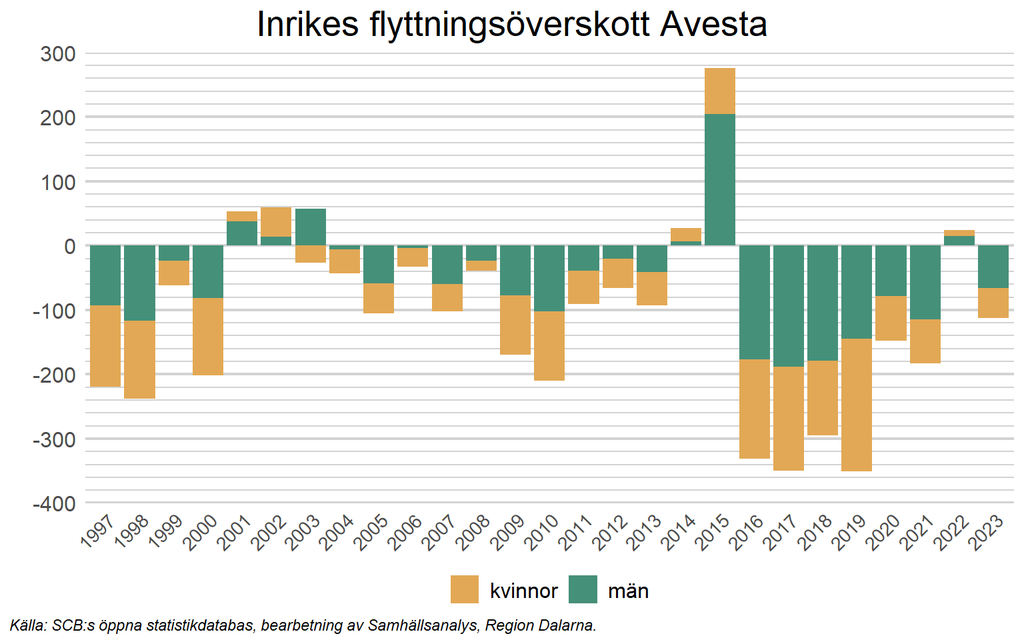

För att få en bättre förståelse för vilka som flyttar till och från kommunen inrikes delar vi härnäst upp de som flyttar efter ålder. Normalt är personer mest benägna att flytta till en annan ort när de är i 20-års åldern, innan flyttandet gradvis avtar.

### 3.2.1 Uppdelat på ålder

Ett tydligt mönster är att de personer under 30 år som flyttar från Avesta är fler än de personer under 30 år som flyttar dit, dvs. kommunen förlorar invånare i den åldersgruppen på grund av inrikes flyttar. Inom andra åldersgrupper är tendenserna mer otydliga, då antalet in- och utflyttare (netto) varierar relativt mycket mellan åren.

Bland de åldersgrupper som redovisas i diagrammet nedan skedde den största utflyttningen år 2023 i gruppen som är under 20 år. I denna grupp, tillsammans med de som är mellan 20 år och 30 år, var antalet utflyttare 118 fler än antalet inflyttare, vilket är en större skillnad än året innan.

Den största inflyttningen, netto, skedde i åldersgruppen 50-59 år, i vilken det flyttade 15 personer fler till än från kommunen inrikes år 2023. Jämfört med åren innan var detta en tydlig ökning.

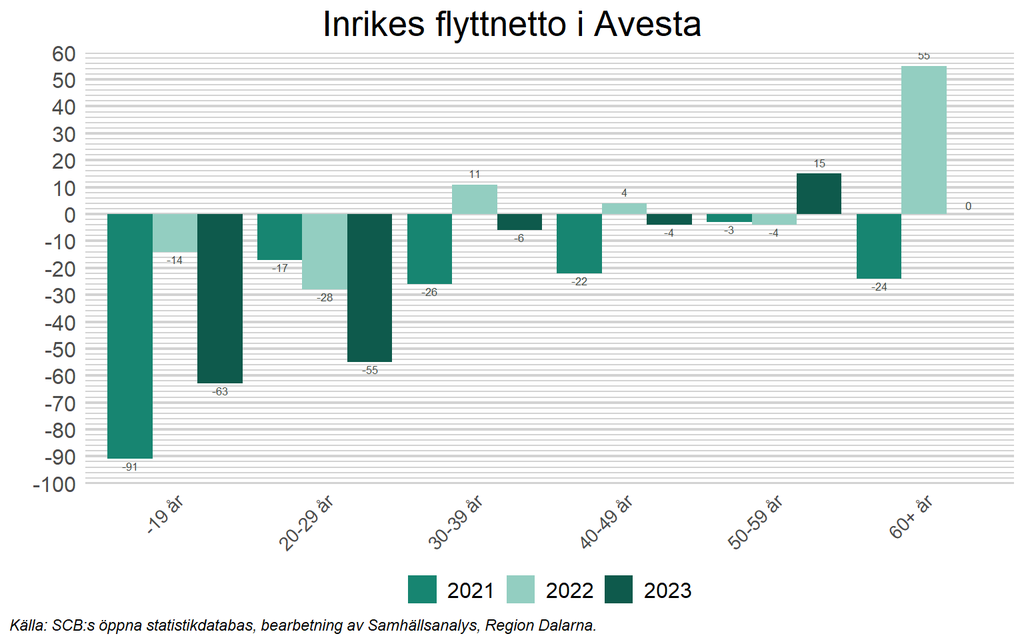

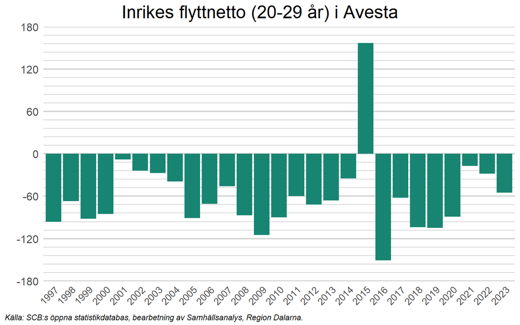

### 3.2.2 Uppdelat på bakgrund

För att ytterligare förtydliga vilka som flyttar till och från Avesta inrikes, delas de i detta avsnitt upp efter sin bakgrund, inrikes eller utrikes födda.

Tydligt är att många av de som invandrade till Avesta i samband med flyktingkrisen 2015-2016 flyttade därifrån under åren efter krisen. Sammantaget har runt 1500 utrikes födda (netto) flyttat från Avesta till andra delar av Sverige sedan 2016.

För de som är födda i Sverige är det inrikes flyttnettot inte lika tydligt. Under åren efter flyktingkrisen lämnade även många inrikes födda Avesta, men på senare år har inflyttningen i den gruppen under vissa år varit större än utflyttningen. Framförallt flyttade många inrikes födda till kommunen under 2022. År 2023 flyttade 17 inrikes födda personer netto från kommunen till anda delar av Sverige.

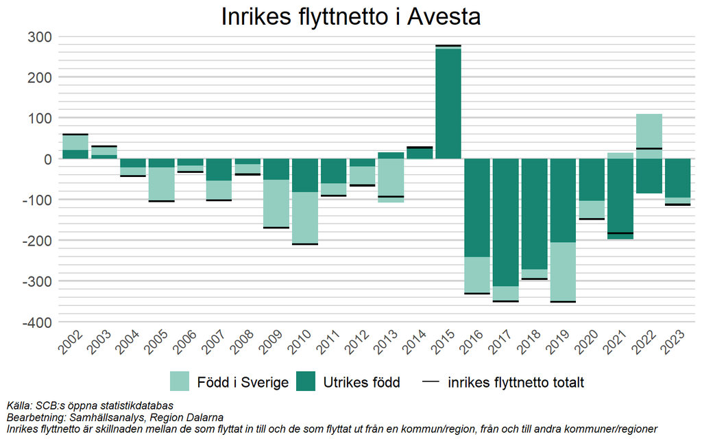

Sammanfattningsvis minskade Avesta folkmängd under 2023 med 179 personer, vilket är den största minskningen sedan 2010. Detta hänger samman med att mer eller mindre alla komponenter som förklar befolkningsutvecklingen försämrades jämfört med året innan.

I nästa avsnitt blickar vi istället framåt. Hur kommer Avestas folkmängd att utvecklas fram till 2040?

# 4 Vad händer i framtiden?

För en djupare förståelse för hur SCB gör befolkningsprognoser, se motsvarande avsnitt i rapporten för hela Dalarnas län.

I diagrammet nedan visas befolkningsutvecklingen i Avesta fram till 2040 enligt SCB:s senaste prognos (juni 2024), uppdelat på åldersgrupper. Ett par tydliga trender kan utläsas i diagrammet:

- Avesta befolkning prognostiseras att minska med drygt 1 600 personer fram till 2040, vilket är en tydlig försämring jämfört med tidigare prognoser. I den föregående prognosen, som släpptes 2022, prognostiserades en minskning på under 700 personer (se [SCB](https://www.statistikdatabasen.scb.se/pxweb/sv/ssd/START__BE__BE0401__BE0401B/BefProgRegFakN22/table/tableViewLayout1/)).
- Den största minskningen sker i gruppen som brukar benämnas arbetsför ålder, 20-64 år, som prognostiseras minska med ungefär 1 000 personer.
- I åldergruppen 80+ förväntas befolkning att öka med strax under 700 fram till 2040. Detta hänger sannolikt samman med att den förväntade livslängden fortsätter öka och att den stora gruppen “baby-boomers” börjar komma upp i 80-års åldern.
- Även i åldersgruppen 0-19 år prognostiseras en relativt stor minskning av befolkningen, ungefär 860 personer.

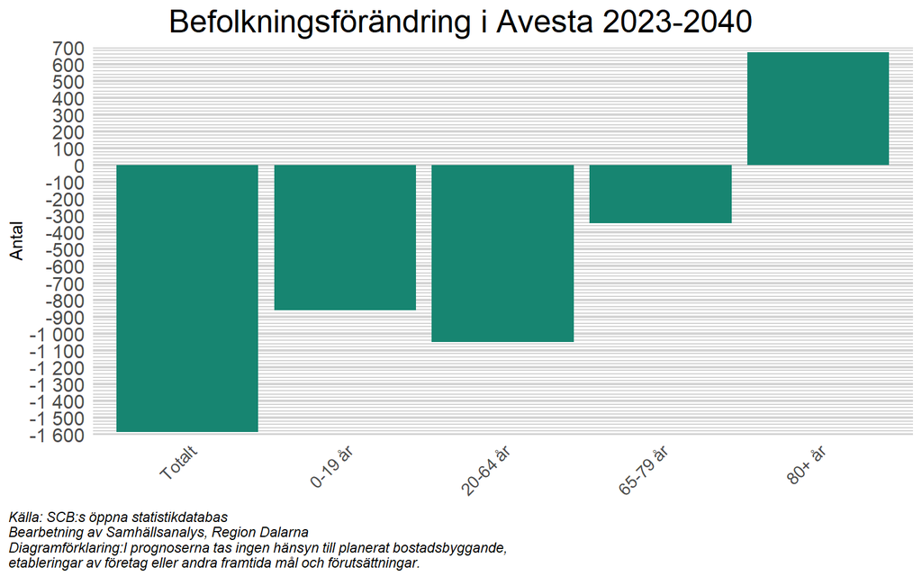

Sammantaget ger SCB:s prognos en föraning om stora utmaningar för Avesta framöver. Befolkningen blir äldre och minskar i antal, vilket sätter press på såväl välfärden som arbetsmarknaden. Hur kommunen möter dessa utmaningar blir en avgörande faktor för dess framtida utveckling.